# GSC Batch 3: Sequence Statistics

##### miRNA species vs. Total miRNA Reads

1. Total miRNA Reads vs Percentage of Reads Mapped

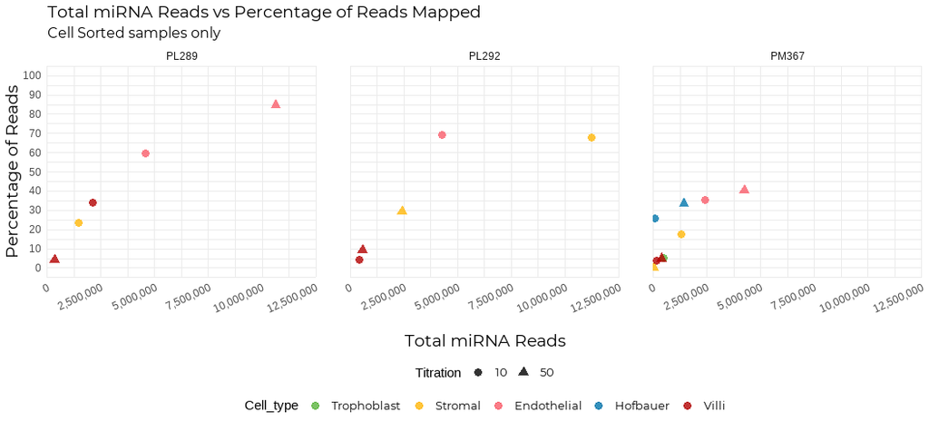

###### 2. Total miRNA species with >=1 read

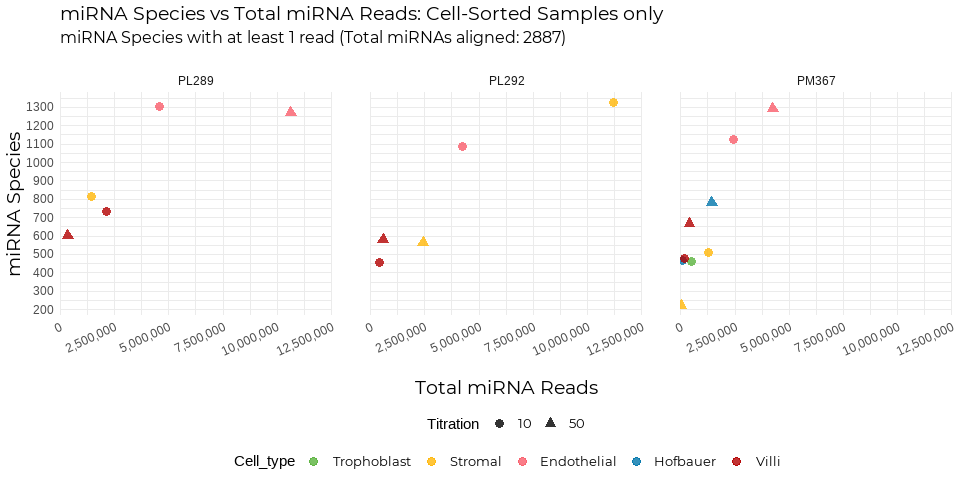

###### 3. Total miRNA species with >=2 read

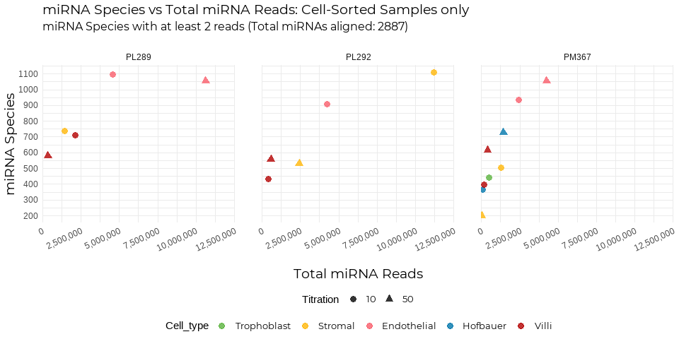

###### 4. Total miRNA species with >=10 reads

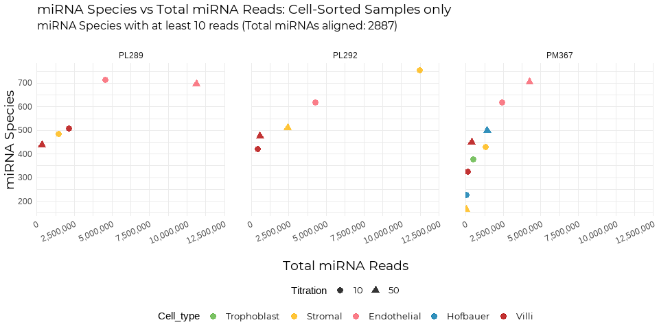

#### 2.5 Comparing Manual vs. miRMaster Aligned Counts

For sample PL289_50 (GSC ID: M20072), I manually aligned the reads using STAR to the reference hg38 genome. I’ll compare a few statistics here:

```r
manual <- read_excel(here::here("Batch_3", "data", "processed", "M20072_counts_manual.xlsx"))
manual_mDat <- read_excel(here::here("Batch_3", "data", "processed", "M20072_counts_manual_mDat.xlsx"))

# manual sequences have already filtered for minimum read count of 2
head(manual)
```

```
## # A tibble: 6 x 2
##   entrezgene_id manual_counts
##   <chr>                 <dbl>
## 1 653635                    2
## 2 102723897                 2
## 3 79854                     2
## 4 148398                    6
## 5 26155                     4
## 6 339451                   11
```

```r
manual_list <- manual_mDat %>%
    split(f = as.factor(.$gene_biotype))

manual_list <- lapply(manual_list, f1)
manual_list <- as.data.frame(unlist(manual_list))


# selecting PL289_50 miRMaster data
M20072_miRMaster <- all %>%
    dplyr::select(Reference, sncRNA, PL289_50)
dim(M20072_miRMaster)
```

```
## [1] 9098    3
```

```r
# filtering to keep min count of 2
M20072_miRMaster <- M20072_miRMaster %>%
    filter(PL289_50 >= 2)
dim(M20072_miRMaster)
```

```
## [1] 3142    3
```

```r
M20072_miRMaster <- M20072_miRMaster %>%
    split(f = as.factor(.$sncRNA))

M20072_miRMaster <- lapply(M20072_miRMaster, f1)
M20072_miRMaster <- as.data.frame(unlist(M20072_miRMaster))

# there's no piRNA and tRNA mapped at all in manual, and it has lncRNA. Will have to
# remove lncRNA and add tRNA and piRNA
sncrownames <- row.names(M20072_miRMaster)
sncrownames
```

```
##  [1] "miRNA.dim1"   "miRNA.dim2"   "miscRNA.dim1" "miscRNA.dim2" "piRNA.dim1"
##  [6] "piRNA.dim2"   "rRNA.dim1"    "rRNA.dim2"    "scaRNA.dim1"  "scaRNA.dim2"
## [11] "snoRNA.dim1"  "snoRNA.dim2"  "snRNA.dim1"   "snRNA.dim2"   "tRNA.dim1"
## [16] "tRNA.dim2"
```

```r
sncrownames <- sncrownames[c(5, 6, 15, 16)]
sncrownames <- as.data.frame(sncrownames)
sncrownames$M20072_manual <- 0
sncrownames <- sncrownames %>%
    column_to_rownames(var = "sncrownames")

# now removing lncRNA and binding sncrownames rows to manual
manual_list <- tail(manual_list, -2)
colnames(manual_list)[1] <- "M20072_manual"
manual_list <- rbind(manual_list, sncrownames)

# let's check that the sncRNAs are in the right order
row.names(manual_list)
```

```
##  [1] "miRNA.dim1"    "miRNA.dim2"    "misc_RNA.dim1" "misc_RNA.dim2"
##  [5] "rRNA.dim1"     "rRNA.dim2"     "scaRNA.dim1"   "scaRNA.dim2"
##  [9] "snoRNA.dim1"   "snoRNA.dim2"   "snRNA.dim1"    "snRNA.dim2"
## [13] "piRNA.dim1"    "piRNA.dim2"    "tRNA.dim1"     "tRNA.dim2"
```

```r
row.names(M20072_miRMaster)
```

```
##  [1] "miRNA.dim1"   "miRNA.dim2"   "miscRNA.dim1" "miscRNA.dim2" "piRNA.dim1"
##  [6] "piRNA.dim2"   "rRNA.dim1"    "rRNA.dim2"    "scaRNA.dim1"  "scaRNA.dim2"
## [11] "snoRNA.dim1"  "snoRNA.dim2"  "snRNA.dim1"   "snRNA.dim2"   "tRNA.dim1"
## [16] "tRNA.dim2"
```

```r
# they're not. Also, manual has miscRNA listed as misc_RNA. Removing that underscrore:
manual_list <- as.data.frame(t(manual_list))
names(manual_list)
```

```
##  [1] "miRNA.dim1"    "miRNA.dim2"    "misc_RNA.dim1" "misc_RNA.dim2"
##  [5] "rRNA.dim1"     "rRNA.dim2"     "scaRNA.dim1"   "scaRNA.dim2"
##  [9] "snoRNA.dim1"   "snoRNA.dim2"   "snRNA.dim1"    "snRNA.dim2"
## [13] "piRNA.dim1"    "piRNA.dim2"    "tRNA.dim1"     "tRNA.dim2"
```

```r
colnames(manual_list)[3:4] <- c("miscRNA.dim1", "miscRNA.dim2")
manual_list <- as.data.frame(t(manual_list))

manual_list <- manual_list %>%
    rownames_to_column(var = "sncRNA")
M20072_miRMaster <- M20072_miRMaster %>%
    rownames_to_column(var = "sncRNA")

M20072 <- manual_list %>%
    inner_join(M20072_miRMaster, by = "sncRNA")
M20072 <- M20072 %>%
    column_to_rownames(var = "sncRNA")
M20072$v <- c("rows", "columns")
M20072 <- M20072 %>%
    filter(v == "rows")
colnames(M20072)[1:2] <- c("M20072_manual", "M20072_miRMaster")
row.names(M20072)
```

```
## [1] "miRNA.dim1"   "miscRNA.dim1" "rRNA.dim1"    "scaRNA.dim1"  "snoRNA.dim1"
## [6] "snRNA.dim1"   "piRNA.dim1"   "tRNA.dim1"
```

```r
row.names(M20072) <- c("miRNA", "miscRNA", "rRNA", "scaRNA", "snoRNA", "snRNA", "piRNA", "tRNA")
M20072 <- M20072[c(1, 2)]
M20072 %>%
    kable()
```

|  | M20072_manual | M20072_miRMaster |
| --- | --- | --- |
| miRNA | 596 | 578 |
| miscRNA | 8 | 773 |
| rRNA | 1 | 54 |
| scaRNA | 12 | 18 |
| snoRNA | 207 | 441 |
| snRNA | 25 | 477 |
| piRNA | 0 | 390 |
| tRNA | 0 | 411 |

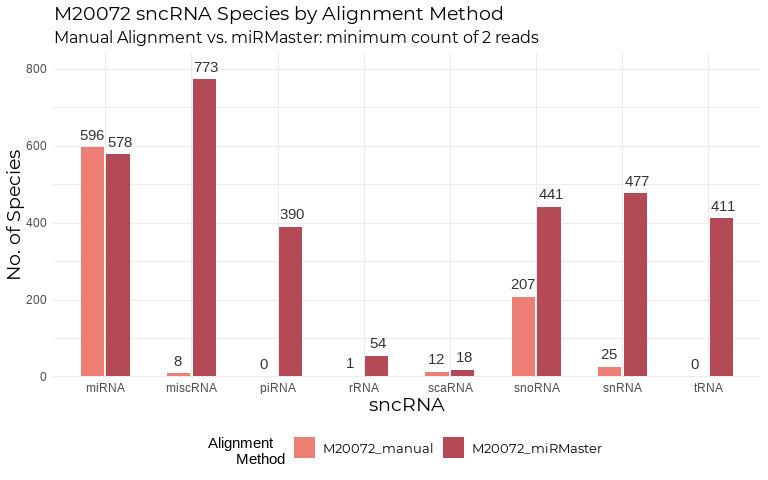

```r
M20072 %>%
    rownames_to_column(var = "sncRNA") %>%
    pivot_longer(cols = 2:3, names_to = "Mapping", values_to = "Species") %>%
    ggplot(aes(x = sncRNA, y = Species, fill = Mapping)) + geom_bar(stat = "identity", position = position_dodge2(preserve = "single"),
    width = 0.6) + geom_text(aes(label = Species), vjust = -0.8, colour = "#333333", position = position_dodge(0.65)) +
    scale_y_continuous(expand = expansion(mult = c(0, 0.09))) + scale_fill_manual(values = c("#ec7e74",
    "#b44a56")) + my_theme + theme(legend.position = "bottom") + labs(title = "M20072 sncRNA Species by Alignment Method",
    subtitle = "Manual Alignment vs. miRMaster: minimum count of 2 reads", x = "sncRNA", y = "No. of Species",
    fill = "Alignment
       Method")
```

The actual expression counts cannot be compared because manual mapping only gives the miRNA in it’s precursor form i.e., mir-21 and miRMaster align it using mir-21-3p and mir-21-5p

### 2.0 PL290v and TCR-5-18

#### 2.1 Total Reads

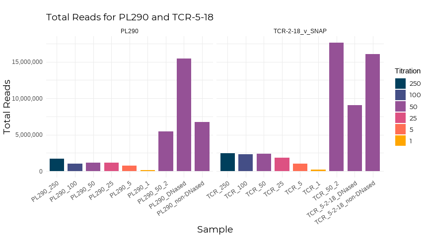

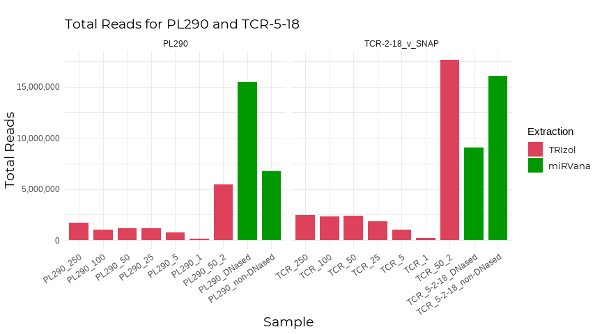

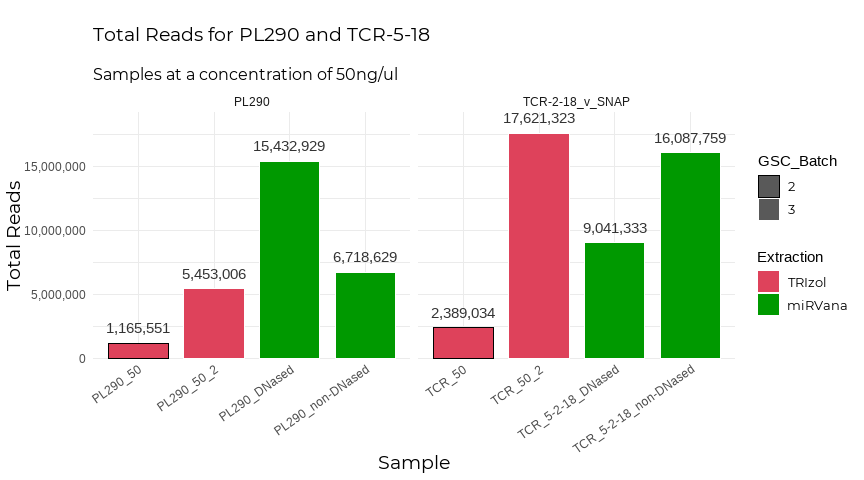

#### 2.2 Species Filtering

I’m going to now count the number of miRNA species for each sample which have:

- At least 1 read count for a species
- At least 2 read counts for a species
- At at least 10 read counts for a species

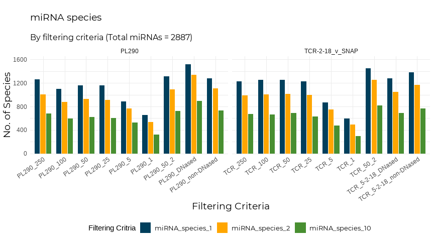

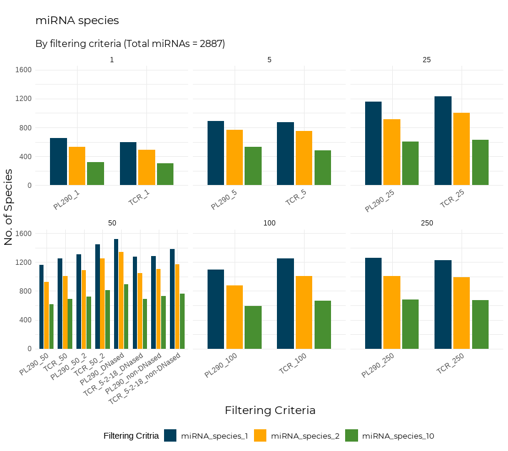

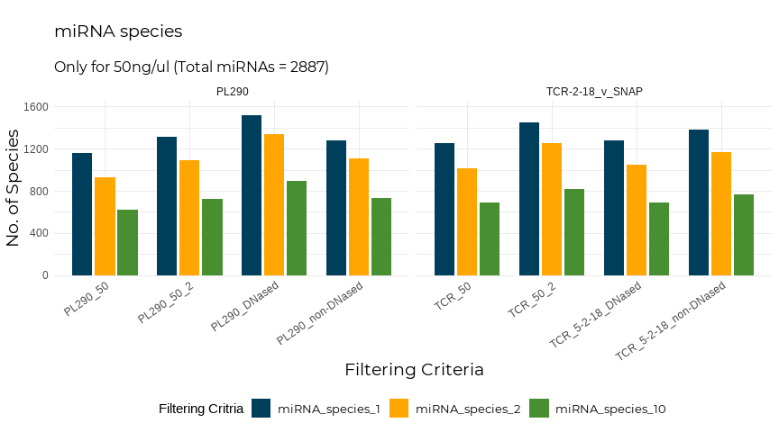

#### 2.2 miRNA species vs. Total miRNA Reads

##### 1. Total miRNA species with >=1 read

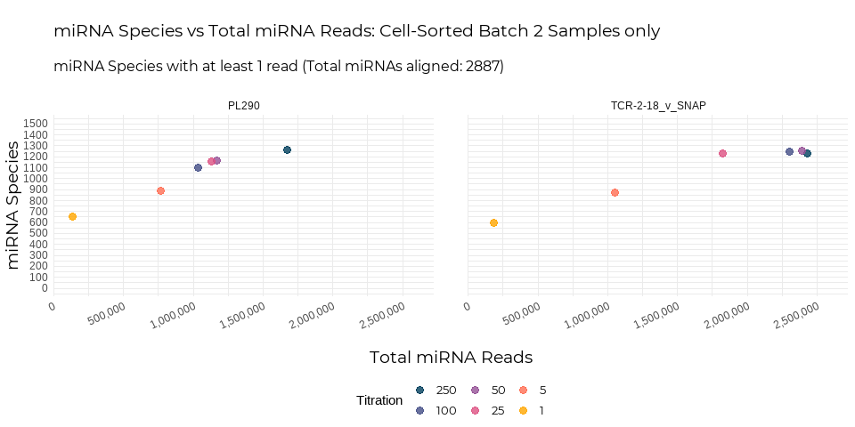

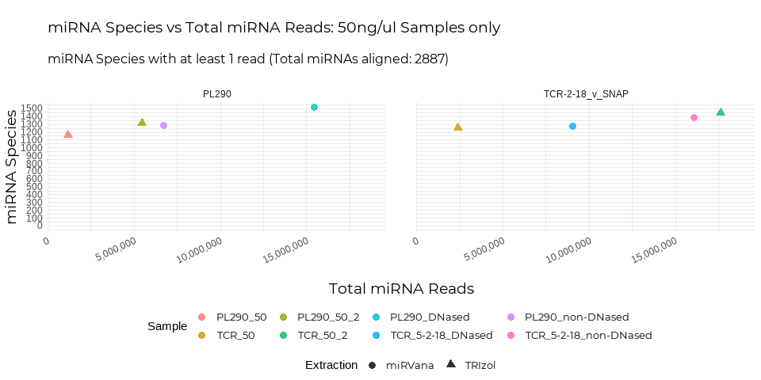

##### 2. Total miRNA species with >=2 reads

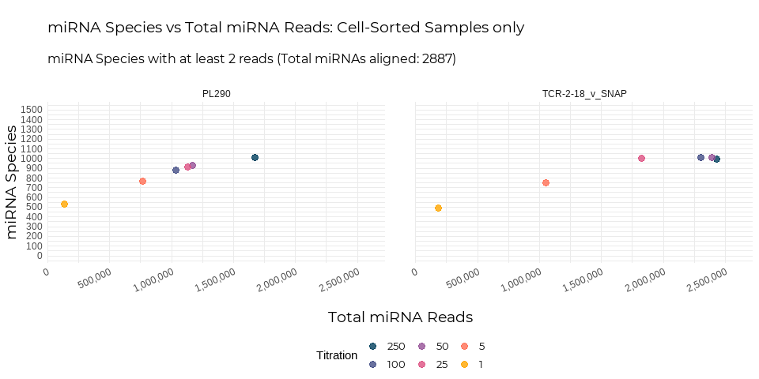

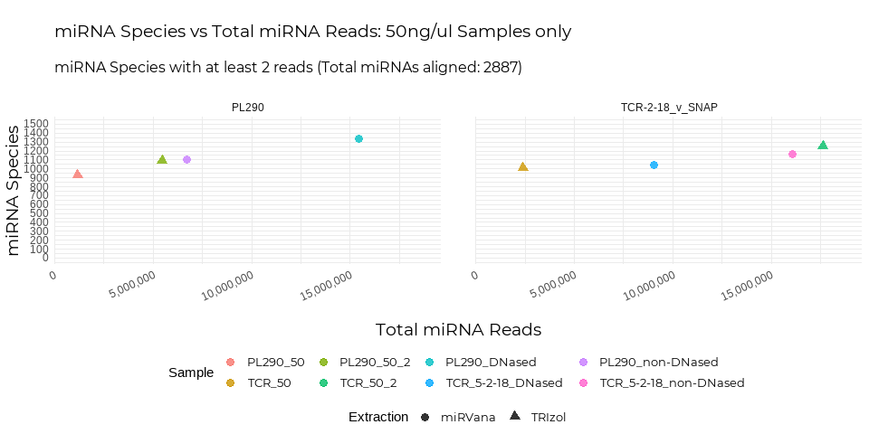

##### 3. Total miRNA species with >=10 reads

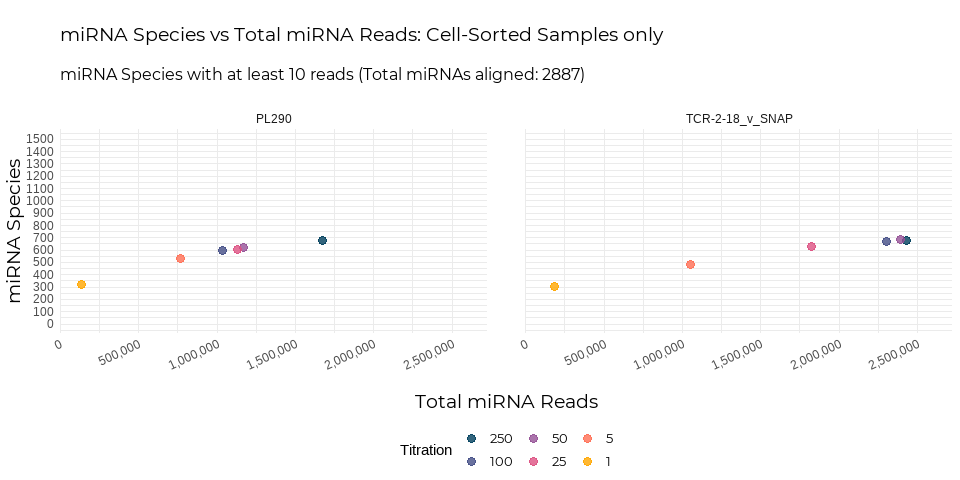

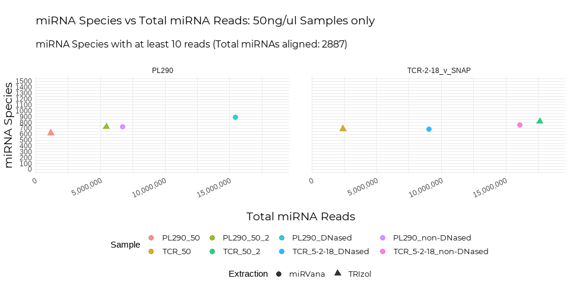

### 3.0 PM384 and PM385

#### 3.1 Total Reads

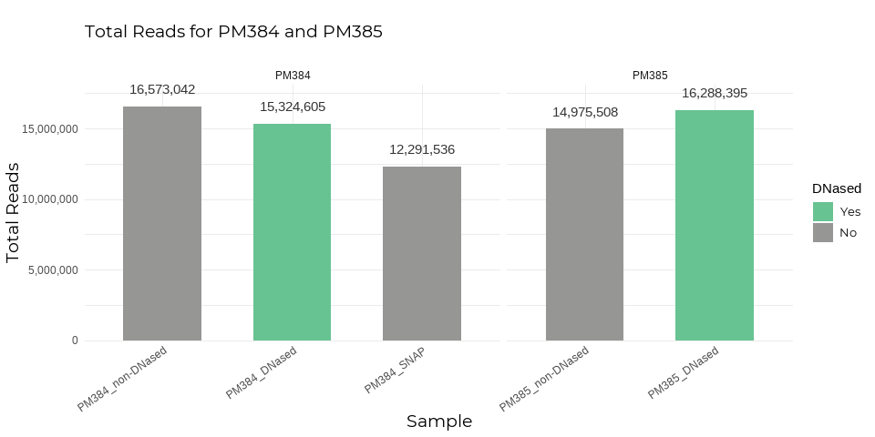

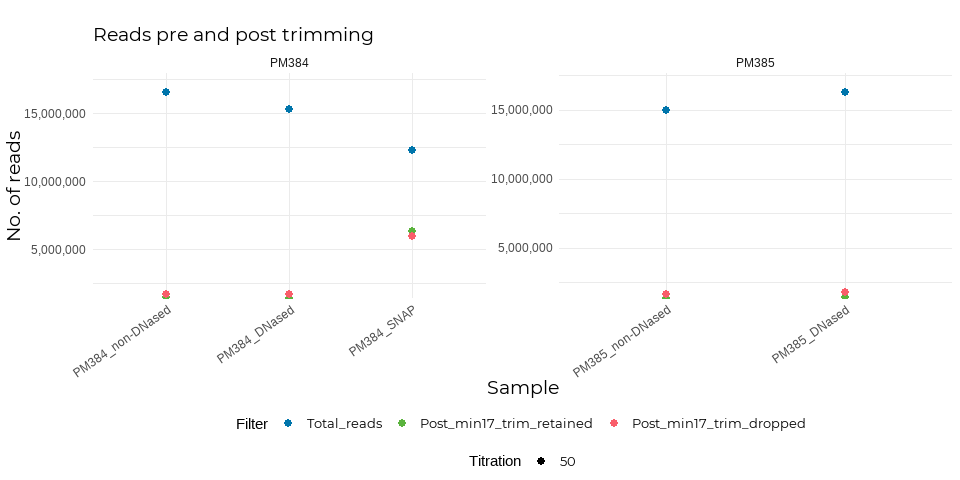

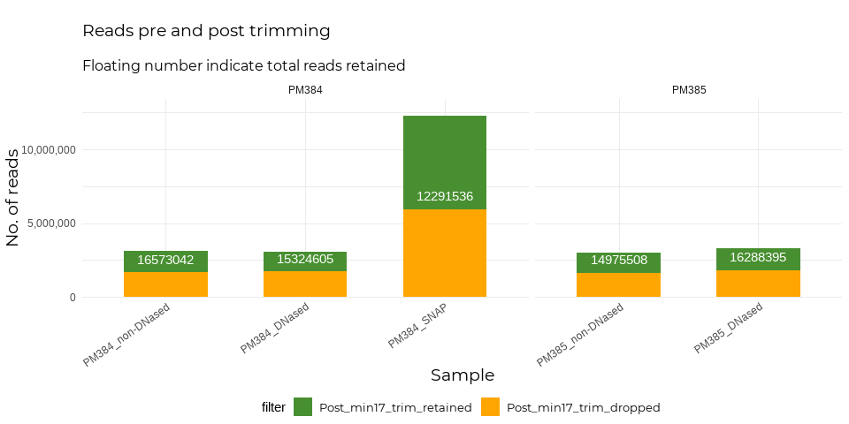

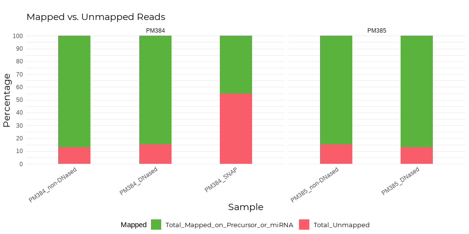

#### 3.2 Species Filtering

I’m going to now count the number of miRNA species for each sample which have:

- At least 1 read count for a species
- At least 2 read counts for a species
- At at least 10 read counts for a species

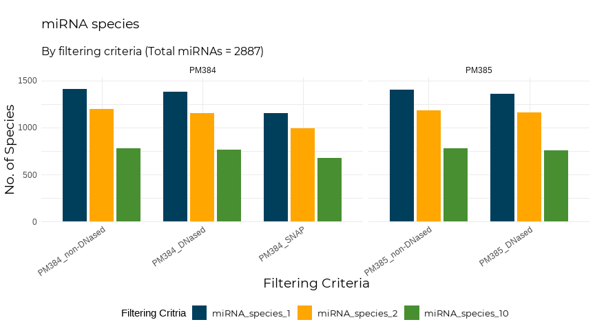